# Moodys Calculation

# Introduction

# Research Problem

Here is the story from Moodys, page 5.

> Income sentiment could mislead

> Persistently strong inflation requires consumers to expect higher incomes that allow them to finance these price increases. A potential silver lining for the Fed is that the net percentage of consumers expecting higher incomes in the next six months has fallen. Historically, this measure of income sentiment is strongly correlated with the Atlanta Fed’s Wage Growth Tracker. We used a Granger causality test to determine if there is a causal relationship between the two. With various lags, income sentiment was found to Granger-cause changes in the Atlanta Fed wage tracker. The causal relationship runs in only one direction.

We could not access the Consumer Confidence Index, prepared by The Conference Board, without paying $995.00. So we went for the University of Michigan’s Index of Consumer Sentiment (ICS) The Atlanta Fed Wage Tracker (AFWT) is publicly available, and we obtained it.

# Packages

We load the standard MBAD packages.

# Custom Packages for MBAD

Install and load:

```r
library(mbadtools)
lib_packages(mbad_standard_packages)
```

```
Loading MBAD packages:
 tidyverse ggfortify GGally skimr broom gt patchwork car yardstick ggResidpanel ggh4x
```

```r
library(lmtest)
```

# Data

The next sections show how to get the data for the Moody report. But we have already installed the data required inthe `mbadtools` package as dataset `moody`.

## Atlanta Fed Wage Tracker

First we load this dataset.

```r
library(readxl)
wage_growth_data <- read_excel("../inst/wage-growth-data.xlsx",
    skip = 1)
glimpse(wage_growth_data)
```

```
Rows: 301
Columns: 15
$ ...1                               <dttm> 1997-01-01, 1997-02-01, 1997-03-01,…
$ `Unweighted Overall`               <chr> ".", ".", "4.5", "4.5999999999999996…
$ Services                           <chr> ".", ".", "4.5999999999999996", "4.7…
$ `Full-time`                        <chr> ".", ".", "4.5", "4.5999999999999996…
$ `College degree`                   <chr> ".", ".", "4.7", "4.5999999999999996…
$ `Prime-age`                        <chr> ".", ".", "4.4000000000000004", "4.5…
$ Female                             <chr> ".", ".", "4.5999999999999996", "4.5…
$ Male                               <chr> ".", ".", "4.4000000000000004", "4.5…
$ `Job Stayer`                       <chr> ".", ".", "4.0999999999999996", "4.0…
$ `Job Switcher`                     <chr> ".", ".", "5.2", "5.4", "5.5", "5.8"…
$ `Paid Hourly`                      <chr> ".", ".", "4.2", "4.3", "4.099999999…
$ `Weighted Overall`                 <chr> ".", ".", "4.9000000000000004", "5",…
$ `Weighted 97 Overall`              <chr> ".", ".", "4.9000000000000004", "5",…
$ `Unweighted Overall: Weekly Basis` <chr> ".", ".", "4.8", "4.9000000000000004…
$ `25/20 trimmed mean`               <dbl> NA, NA, 4.5, 4.5, 4.4, 4.6, 4.8, 4.9…
```

## UM Consumer Confidence

```r
library(readxl)
redbk01a <- read_excel("../inst/redbk01a.xls")
glimpse(redbk01a)
```

```
Rows: 621
Columns: 4
$ `Date  of  Survey` <chr> NA, "November", "February", "August", "November", "F…
$ ...2               <dbl> NA, 1952, 1953, 1953, 1953, 1954, 1954, 1954, 1955, …
$ ICS                <dbl> NA, 86.2, 90.7, 80.8, 80.7, 82.0, 82.9, 87.0, 95.9, …
$ Cases              <dbl> NA, 1714, 3097, 1022, 1023, 3000, 1365, 1139, 3119, …
```

# Data Description

Fed Wage Growth Data:

```r
wage_growth_data
```

| ...1 | Unweighted Overall | Services | Full-time | College degree | Prime-age | Female | Male | Job Stayer | Job Switcher | Paid Hourly | Weighted Overall | Weighted 97 Overall | Unweighted Overall: Weekly Basis | 25/20 trimmed mean |
| --- | --- | --- | --- | --- | --- | --- | --- | --- | --- | --- | --- | --- | --- | --- |
| 1997-01-01 | . | . | . | . | . | . | . | . | . | . | . | . | . | NA |
| 1997-02-01 | . | . | . | . | . | . | . | . | . | . | . | . | . | NA |
| 1997-03-01 | 4.5 | 4.5999999999999996 | 4.5 | 4.7 | 4.4000000000000004 | 4.5999999999999996 | 4.4000000000000004 | 4.0999999999999996 | 5.2 | 4.2 | 4.9000000000000004 | 4.9000000000000004 | 4.8 | 4.5 |
| 1997-04-01 | 4.5999999999999996 | 4.7 | 4.5999999999999996 | 4.5999999999999996 | 4.5 | 4.5 | 4.5999999999999996 | 4.0999999999999996 | 5.4 | 4.3 | 5 | 5 | 4.9000000000000004 | 4.5 |
| 1997-05-01 | 4.5 | 4.5 | 4.5999999999999996 | 4.5 | 4.4000000000000004 | 4.5 | 4.5 | 4 | 5.5 | 4.0999999999999996 | 4.9000000000000004 | 5 | 4.8 | 4.4 |
| 1997-06-01 | 4.5999999999999996 | 4.5999999999999996 | 4.5999999999999996 | 4.7 | 4.5 | 4.8 | 4.5999999999999996 | 4.0999999999999996 | 5.8 | 4.4000000000000004 | 5 | 5 | 5.0999999999999996 | 4.6 |
| 1997-07-01 | 4.8 | 4.7 | 4.7 | 4.9000000000000004 | 4.5999999999999996 | 5.0999999999999996 | 4.5 | 4.2 | 5.9 | 4.5 | 5.0999999999999996 | 5.0999999999999996 | 5.0999999999999996 | 4.8 |
| 1997-08-01 | 4.9000000000000004 | 5 | 4.8 | 5.0999999999999996 | 4.5999999999999996 | 5.2 | 4.7 | 4.3 | 6.1 | 4.7 | 5.2 | 5.0999999999999996 | 5.3 | 4.9 |
| 1997-09-01 | 4.8 | 4.9000000000000004 | 4.8 | 5 | 4.5 | 4.9000000000000004 | 4.8 | 4.3 | 5.8 | 4.5 | 5.0999999999999996 | 5 | 5 | 4.8 |
| 1997-10-01 | 4.8 | 4.9000000000000004 | 4.7 | 5 | 4.5 | 4.8 | 4.8 | 4.4000000000000004 | 5.6 | 4.5 | 5 | 5 | 5 | 4.7 |

[output cut: 291 more lines]

```r
redbk01a
```

| Date of Survey | ...2 | ICS | Cases |
| --- | --- | --- | --- |
| NA | NA | NA | NA |
| November | 1952 | 86.2 | 1714 |
| February | 1953 | 90.7 | 3097 |
| August | 1953 | 80.8 | 1022 |
| November | 1953 | 80.7 | 1023 |
| February | 1954 | 82.0 | 3000 |
| May | 1954 | 82.9 | 1365 |
| November | 1954 | 87.0 | 1139 |
| February | 1955 | 95.9 | 3119 |
| May | 1955 | 99.1 | 1007 |

[output cut: 611 more lines]

# Data Wrangling

## AFWT

```r
waget = wage_growth_data %>% select(1,2) %>% rename(Date=1, Wgrowth=2) %>%
  mutate(Wgrowth=as.numeric(Wgrowth)) %>% na.omit %>%
  mutate(Month = lubridate::month(Date), Year=lubridate::year(Date))
glimpse(waget)
```

```
Rows: 299
Columns: 4
$ Date    <dttm> 1997-03-01, 1997-04-01, 1997-05-01, 1997-06-01, 1997-07-01, 19…
$ Wgrowth <dbl> 4.5, 4.6, 4.5, 4.6, 4.8, 4.9, 4.8, 4.8, 4.8, 4.9, 4.9, 4.8, 4.6…
$ Month   <dbl> 3, 4, 5, 6, 7, 8, 9, 10, 11, 12, 1, 2, 3, 4, 5, 6, 7, 8, 9, 10,…
$ Year    <dbl> 1997, 1997, 1997, 1997, 1997, 1997, 1997, 1997, 1997, 1997, 199…
```

Visualizing:

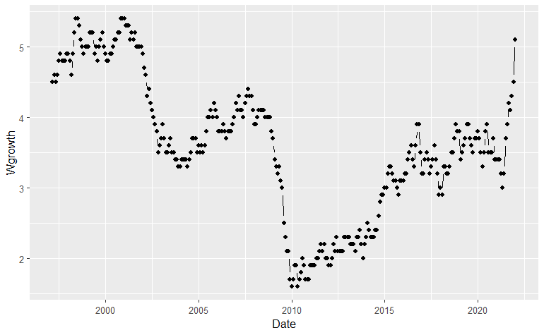

```r
waget %>% ggplot() +
  geom_pointpath(aes(Date, Wgrowth))
```

## ICS

```r
umics = redbk01a %>%
  rename(Month=`Date  of  Survey`, Year=2) %>% na.omit %>%
  mutate(Mo = match(Month, month.name)) %>%
  mutate(Date=paste0(Year,"-",Mo,"-01"),
         Datep=as.POSIXct(as.Date(Date))%m+%months(1))
glimpse(umics)
```

```
Rows: 620
Columns: 7
$ Month <chr> "November", "February", "August", "November", "February", "May", …
$ Year  <dbl> 1952, 1953, 1953, 1953, 1954, 1954, 1954, 1955, 1955, 1955, 1956,…
$ ICS   <dbl> 86.2, 90.7, 80.8, 80.7, 82.0, 82.9, 87.0, 95.9, 99.1, 99.7, 98.2,…
$ Cases <dbl> 1714, 3097, 1022, 1023, 3000, 1365, 1139, 3119, 1007, 1030, 1676,…
$ Mo    <int> 11, 2, 8, 11, 2, 5, 11, 2, 5, 11, 5, 8, 11, 5, 11, 2, 5, 11, 5, 1…
$ Date  <chr> "1952-11-01", "1953-2-01", "1953-8-01", "1953-11-01", "1954-2-01"…
$ Datep <dttm> 1952-12-01, 1953-03-01, 1953-09-01, 1953-12-01, 1954-03-01, 1954…
```

```r
umics
```

| Month | Year | ICS | Cases | Mo | Date | Datep |
| --- | --- | --- | --- | --- | --- | --- |
| November | 1952 | 86.2 | 1714 | 11 | 1952-11-01 | 1952-12-01 |
| February | 1953 | 90.7 | 3097 | 2 | 1953-2-01 | 1953-03-01 |
| August | 1953 | 80.8 | 1022 | 8 | 1953-8-01 | 1953-09-01 |
| November | 1953 | 80.7 | 1023 | 11 | 1953-11-01 | 1953-12-01 |
| February | 1954 | 82.0 | 3000 | 2 | 1954-2-01 | 1954-03-01 |
| May | 1954 | 82.9 | 1365 | 5 | 1954-5-01 | 1954-06-01 |
| November | 1954 | 87.0 | 1139 | 11 | 1954-11-01 | 1954-12-01 |
| February | 1955 | 95.9 | 3119 | 2 | 1955-2-01 | 1955-03-01 |
| May | 1955 | 99.1 | 1007 | 5 | 1955-5-01 | 1955-06-01 |
| November | 1955 | 99.7 | 1030 | 11 | 1955-11-01 | 1955-12-01 |

[output cut: 610 more lines]

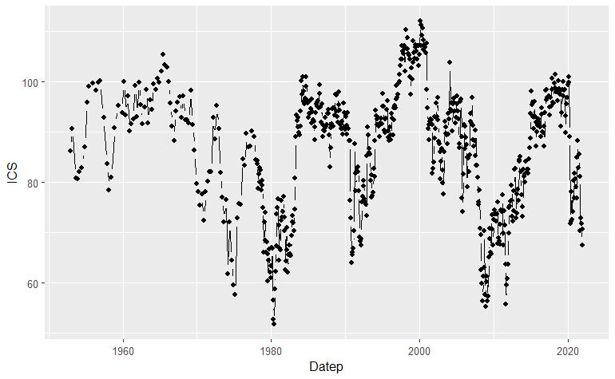

```r
umics %>% ggplot() +
  geom_pointpath(aes(Datep,ICS))
```

And plotting together:

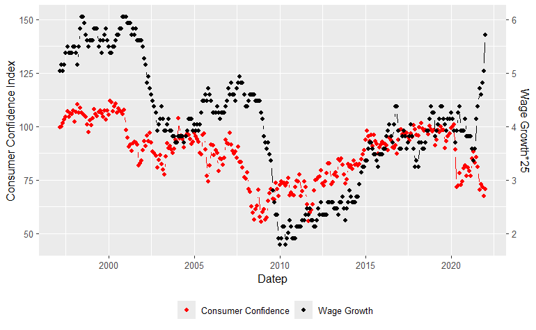

```r
ggplot(umics %>% dplyr::filter(Datep>=waget[1,]$Date)) +
  geom_pointpath(aes(Datep,ICS, color="Consumer Confidence")) +
  geom_pointpath(aes(Date,Wgrowth*28, color="Wage Growth"),
                 data=waget) +
  # labs(y="ICS and Wage Growth*25") +
  scale_color_manual(values=c("red","black"), name="")+
  theme(legend.position = "bottom") +
  scale_y_continuous(name = "Consumer Confidence Index",
    sec.axis = sec_axis(~./25, name = "Wage Growth*25"))
```

It seems like Wage growth starts latest, so we must select only data in its data range for inclusion.

```r
waget[1,]$Date
```

```
[1] "1997-03-01 UTC"
```

```r
umics1 = umics %>%
  dplyr::filter(Datep>=waget[1,]$Date) %>%
  select(Datep, ICS) #%>%
umics2 = umics1 %>% mutate(Datep=Datep + days(1) + hours(6) + minutes(59))
waget1 = waget %>% select(Date, Wgrowth)
data.frame(umics2, waget1)
```

| Datep | ICS | Date | Wgrowth |
| --- | --- | --- | --- |
| 1997-03-02 06:59:00 | 99.7 | 1997-03-01 | 4.5 |
| 1997-04-02 06:59:00 | 100.0 | 1997-04-01 | 4.6 |
| 1997-05-02 06:59:00 | 101.4 | 1997-05-01 | 4.5 |
| 1997-06-02 06:59:00 | 103.2 | 1997-06-01 | 4.6 |
| 1997-07-02 06:59:00 | 104.5 | 1997-07-01 | 4.8 |
| 1997-08-02 06:59:00 | 107.1 | 1997-08-01 | 4.9 |
| 1997-09-02 06:59:00 | 104.4 | 1997-09-01 | 4.8 |
| 1997-10-02 06:59:00 | 106.0 | 1997-10-01 | 4.8 |
| 1997-11-02 06:59:00 | 105.6 | 1997-11-01 | 4.8 |
| 1997-12-02 06:59:00 | 107.2 | 1997-12-01 | 4.9 |

[output cut: 289 more lines]

# The `moody` Data

```r
data(moody, package="mbadtools")
glimpse(moody)
```

```
Rows: 299
Columns: 3
$ Date    <dttm> 1997-03-01, 1997-04-01, 1997-05-01, 1997-06-01, 1997-07-01, 19…
$ Wgrowth <dbl> 4.5, 4.6, 4.5, 4.6, 4.8, 4.9, 4.8, 4.8, 4.8, 4.9, 4.9, 4.8, 4.6…
$ ICS     <dbl> 99.7, 100.0, 101.4, 103.2, 104.5, 107.1, 104.4, 106.0, 105.6, 1…
```

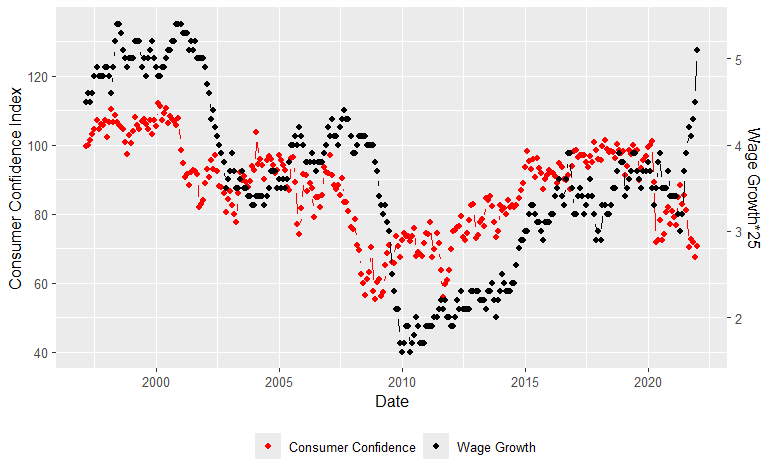

```r
ggplot(moody) +
  geom_pointpath(aes(Date,ICS, color="Consumer Confidence")) +
  geom_pointpath(aes(Date,Wgrowth*25, color="Wage Growth")) +
  # labs(y="ICS and Wage Growth*25") +
  scale_color_manual(values=c("red","black"), name="")+
  theme(legend.position = "bottom") +
  scale_y_continuous(name = "Consumer Confidence Index",
    sec.axis = sec_axis(~./25, name = "Wage Growth*25"))
```

It seems that consumer confidence drops hard just after wage growth peaks. The `moody` data matches the data gleaned form the other sources.

# Granger Causality

We will test Granger causality between these two series, using 4 lags, with the `lmtest::grangertest()` function. Its limitation is that you have to do one lag at a time, and one direction at a time.

## `ICS` =G=> `Wgrowth`

```r
lmtest::grangertest(Wgrowth~ICS, data=moody, order=4)
```

```
Granger causality test

Model 1: Wgrowth ~ Lags(Wgrowth, 1:4) + Lags(ICS, 1:4)
Model 2: Wgrowth ~ Lags(Wgrowth, 1:4)
  Res.Df Df      F  Pr(>F)
1    286
2    290 -4 3.1737 0.01421 *
---
Signif. codes:  0 ‘***’ 0.001 ‘**’ 0.01 ‘*’ 0.05 ‘.’ 0.1 ‘ ’ 1
```

Yes, it appears `ICS` does Granger-cause `Wgrowth`.

## `Wgrowth` =G=> `ICS`

```r
lmtest::grangertest(ICS~Wgrowth, data=moody, order=4)
```

```
Granger causality test

Model 1: ICS ~ Lags(ICS, 1:4) + Lags(Wgrowth, 1:4)
Model 2: ICS ~ Lags(ICS, 1:4)
  Res.Df Df      F Pr(>F)
1    286
2    290 -4 0.8998 0.4644
```

`Wgrowth` does not Granger-cause `ICS.`

# Granger Causality with `mbadtools`

We will tune the order parameter, which represents the number of lags, by choosing different lags of 1 through 10 (or a user-chosen number) for the Granger-causality test. We’ll run both directions of causality, and plot the results. Package `mbadtools` contains functions to test and plot for all lags up to a number given by `max.lags`, which defaults to 10.

Test the `moody` data with `wgrowth` and `ICS`.

```r
moody %>% str
```

```
'data.frame':   299 obs. of  3 variables:
 $ Date   : POSIXct, format: "1997-03-01" "1997-04-01" ...
 $ Wgrowth: num  4.5 4.6 4.5 4.6 4.8 4.9 4.8 4.8 4.8 4.9 ...
 $ ICS    : num  99.7 100 101.4 103.2 104.5 ...
```

The dataset is a data frame. so we use the data frame functions from `mbadtools`.

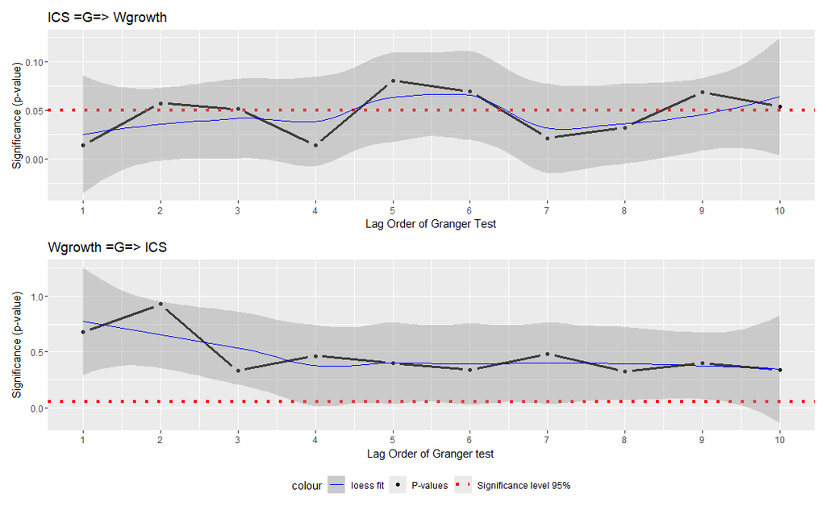

```r
moody %>% GrangerTable(ICS, Wgrowth) %>%
  GrangerPlot() %>% patchwork::wrap_plots(nrow=2)
```

We can also do it as a time series.

```r
ICSt = moody %>% select(ICS) %>% ts
Wgrt = moody %>% select(Wgrowth) %>% ts
GrangerTestPvals(ICSt, Wgrt)
```

| lag | p12 | p21 |
| --- | --- | --- |
| 1 | 0.6761335 | 0.01438965 |
| 2 | 0.9287554 | 0.05774364 |
| 3 | 0.3313588 | 0.05170323 |
| 4 | 0.4644326 | 0.01421188 |
| 5 | 0.3995479 | 0.08115855 |
| 6 | 0.3381422 | 0.06994864 |
| 7 | 0.4797169 | 0.02180274 |
| 8 | 0.3253087 | 0.03273354 |
| 9 | 0.4023939 | 0.06905681 |
| 10 | 0.3413412 | 0.05444012 |

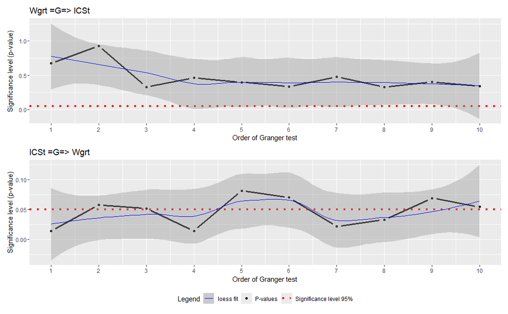

```r
GrangerTestTune(ICSt, Wgrt) %>% patchwork::wrap_plots(nrow=2)
```

Clearly ICS =G=> Wgrowth, with better than .05 p-value for lags 1, 4, 7, and 8. And for all lags, p-value is below .10.

On the other hand, Wgrowth !=G=> ICS for any tested lag, with all p-values exceeding .25.

# EU Stock Markets

This dataset from the `datasets` package contains time series of four indices from the EU stockmarkets. Does any of them Granger-cause another? We will test `FTSE` and `DAX`.

Perform Granger causality test (e.g., `DAX` causing `FTSE` and the reverse), using a data frame:

```r
data(EuStockMarkets)
EuStockMarkets %>% glimpse
```

```
 Time-Series [1:1860, 1:4] from 1991 to 1999: 1629 1614 1607 1621 1618 ...
 - attr(*, "dimnames")=List of 2
  ..$ : NULL
  ..$ : chr [1:4] "DAX" "SMI" "CAC" "FTSE"
```

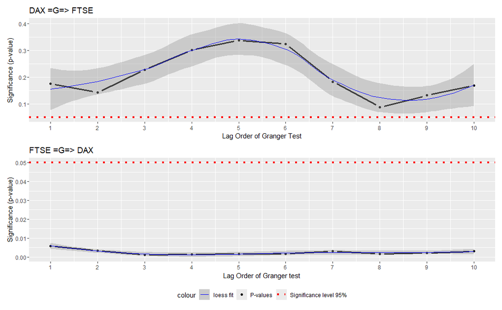

```r
# Convert to data frame for non-time-series handling.
EuStockMarkets %>% data.frame %>%
  GrangerTable(DAX, FTSE) %>%
  GrangerPlot() %>% patchwork::wrap_plots(nrow=2)
```

Using time-series directly: columns of `EuStockMarkets` are time series.

```r
DAX = EuStockMarkets[,"DAX"]
FTSE = EuStockMarkets[,"FTSE"]
GrangerTestPvals(DAX, FTSE)
```

| lag | p12 | p21 |
| --- | --- | --- |
| 1 | 0.005883271 | 0.1752308 |
| 2 | 0.003388300 | 0.1431225 |
| 3 | 0.001033314 | 0.2271553 |
| 4 | 0.001290408 | 0.3011233 |
| 5 | 0.001631223 | 0.3369717 |
| 6 | 0.001645519 | 0.3231901 |
| 7 | 0.003031719 | 0.1833050 |
| 8 | 0.001688721 | 0.0878537 |
| 9 | 0.002116416 | 0.1324406 |
| 10 | 0.003008076 | 0.1696185 |

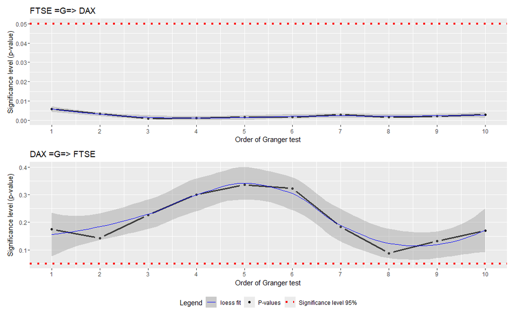

```r
GrangerTestTune(DAX, FTSE) %>%
  wrap_plots(nrow=2)
```

# Conclusion

Our result confirms what the Moodys article says. Consumer confidence Granger-causes Wage growth, but not the reverse. This is telling, because consumer confidence should lead to more spending, and that would generate wage growth.

We also tested FTSE and DAX indices from the `EUStockMarkets` dataset. We found that FTSE Granger-causes DAX, but not the reverse.

# References

1. https://www.moodys.com/researchdocumentcontentpage.aspx?docid=PBC_1319860
2. https://data.sca.isr.umich.edu/tables.php